# **Experiment 3**

#### **Aim**: The aim of this experiment is to extract and analyze Histogram of Oriented Gradients (HoG) features from an image for object recognition or feature analysis. By resizing the image to dimensions that are multiples of 8, computing HoG features with specified parameters, and visualizing the results, we aim to understand how different parameter values influence feature extraction.

### **Name**: Rishikeshh Vadodaria

### **Roll no**: C114

```python
# Dependencies
import cv2
import numpy as np
import matplotlib.pyplot as plt
from skimage.feature import hog
from skimage import color
from skimage.io import imread
from skimage.transform import resize
from skimage import exposure
```

```python
image = imread("tajmahal.jpg")
```

```python
image = resize(image, (224, 336))
```

[figure not shown]

```python
plt.title("Original Image")
plt.imshow(image)
```

```python
fd, hog_image = hog(
    image,
    orientations=9,
    pixels_per_cell=(8, 8),
    cells_per_block=(4, 4),
    visualize=True,
    channel_axis=-1
)
```

```python
fd, hog_image_32 = hog(
    image,
    orientations=9,
    pixels_per_cell=(32, 32),
    cells_per_block=(4, 4),
    visualize=True,
    channel_axis=-1
)
```

[figure not shown]

```python
plt.figure(figsize=(18, 6))


plt.subplot(1, 3, 1)
plt.title("Original Image")
plt.axis("off")
plt.imshow(image, cmap="gray" if len(image.shape) == 2 else None)

plt.subplot(1, 3, 2)
plt.title("HoG Visualization (8x8 cell and 4x4 block)")
plt.axis("off")
plt.imshow(hog_image, cmap="gray")

plt.subplot(1, 3, 3)
plt.title("HoG Visualization (32x32 cell and 4x4 block)")
plt.axis("off")
plt.imshow(hog_image_32, cmap="gray")

plt.tight_layout()
plt.show()
```

```python
percentile2, percentile98 = np.percentile(hog_image, (2, 98))
hog_image = exposure.rescale_intensity(hog_image, in_range=(percentile2, percentile98))
```

[figure not shown]

```python
plt.title("HoG Visualization intensity")
plt.imshow(hog_image, cmap="gray")
plt.show()
```

```python
len(fd)
```

```
4032
```

### Image 2

```python
image2 = imread("Anastronautridingahorse.webp")
```

```python
height, width, channels = image2.shape
print(f"Width: {width}, Height: {height}")
```

```
Width: 1024, Height: 1024
```

[figure not shown]

```python
plt.title("Original Image")
plt.imshow(image2)
```

```python
fd, hog_image2 = hog(
    image2,
    orientations=9,
    pixels_per_cell=(8, 8),
    cells_per_block=(4, 4),
    visualize=True,
    channel_axis=-1
)
```

```python
fd, hog_image_2_32 = hog(
    image2,
    orientations=9,
    pixels_per_cell=(16, 16),
    cells_per_block=(4, 4),
    visualize=True,
    channel_axis=-1
)
```

[figure not shown]

```python
plt.figure(figsize=(18, 6))


plt.subplot(1, 3, 1)
plt.title("Original Image")
plt.axis("off")
plt.imshow(image2, cmap="gray" if len(image.shape) == 2 else None)

plt.subplot(1, 3, 2)
plt.title("HoG Visualization (8x8 cell and 4x4 block)")
plt.axis("off")
plt.imshow(hog_image2, cmap="gray")

plt.subplot(1, 3, 3)
plt.title("HoG Visualization (32x32 cell and 4x4 block)")
plt.axis("off")
plt.imshow(hog_image_2_32, cmap="gray")

plt.tight_layout()
plt.show()
```

```python
percentile2, percentile98 = np.percentile(hog_image2, (2, 98))
hog_image2 = exposure.rescale_intensity(hog_image2, in_range=(percentile2, percentile98))
```

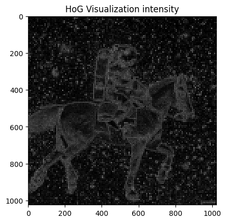

```python
plt.title("HoG Visualization intensity")
plt.imshow(hog_image2, cmap="gray")
plt.show()
```

```python
len(fd)
```

[output not shown]

# **Conclusion:**

HOG Vector and HOG Image are generated Using Histogram of Gradients for the given Image, "tajmahal.JPG".

It is observed that if size of cell is 8,8 pixels and size of blog is 4,4 cells then length of HOG vector is **140400**.

The above combination shows the texture of walls of Taj Mahel on visualization of HOG.

If Size of pixels per cell is increased to 32,32 then length of HOG Vector is **4032**.

HOG Image shows boundaries of the objects like minaret and dome and not Texture.

Each cell on visualized image shows 9 orientations (from 0 to 180 and 0 to -180 degrees)